# Team DAY Project

Dustin Bracy, Adam Ruthford, Yang Zhang

1/23/2020

## Introduction

We would like to answer the following questions about our data: 1. Can we accurately predict the runtime of our reports? 2. What is the expected average delivery time of a one off report? 3. What are the best & worst times of day, week, or month to run a report? 4. Is there a difference in performance between report servers? 5. What are the biggest impacts on performance of reports?

## Data Description

We have collected a full year worth of report data spanning Jan 2019 - Jan 2020. The available parameter list is very large. A description of fields is avaiable below:

#### Report Parameters:

- GroupFI - Fully Insured Client
- GroupSF - Self Funded Client
- Agents - Specified agents
- CurrencyCode - Collection of different lines of business
- GroupCustom - Collection of different client types
- SchedFreq - Scheduled Report Frequency

#### Report Metrics:

- ReportBytes - size in bytes of completed report
- Server - Server on which the report was built
- FormID - Uniquely identifies collection of report parameters
- QueueID - Uniquely identifies queued reports
- QueuedDateTime - when report entered queue
- RenderStartDateTime - when server began work on queued report(s) in queueID batch
- ReportStartDateTime - when server began work on individual report
- ReportEndDateTime - when server completed work on individual report
- RenderEndDateTime - when server completed work on queued report(s) in queueID batch
- Priority - controlled report parameter

#### Engineered Features:

- ReportBuildTime - ReportEndDateTime less ReportStartDateTime
- ReportDeliveryTime - RenderEndDateTime less QueuedDateTime
- LagTime - RenderEndDateTime less ReportEndDateTime
- QueueTime - RenderStartDateTime less QueuedDateTime
- DayOfMonth - Day of the month report ran
- DayOfWeek - Day of the week report ran
- HourOfDay - Hour of the day report ran
- NumberOfQueuedReports - How many reports are in the queue and/or processing when the report begins rendering

### Report Category Crosswalk:

Eligibility “Eligibility”,“Accumulator”,“EventHistory”,“COBRA”,“RedCard”,“ComPsych”

Miscellaneous “Miscellaneous”

Reinsurance “Reinsurance”,“Aggregate Report”

Professional Liability “PL”

Actuarial “Actuarial”,“ISBReports”,“Renewal”, **One exception: when rptCategoryDesc = ‘renewal’ and reportGroup = ‘CommissionsTFB’ use ‘Commissions’**

Finance Commission “Commissions”,“CRMOnlineFinance”,“CommCnt”,“CommCompare”

Claims “ClaimsAudit”,“CMSRepting”,“Repository”,“GilsbarPPO”,“Claims”

Medical Management “Wellness Repository”,“MedCom”,“TVC”,“MedInsight”

Metrics “iTrac”,“TMS”,“Customer Service”,“ODR Admin”,“PortalStats”,“AutoAdjudication”,“Genelco”,“Supervisor”

Extract “DataExtracts”,“Large Claims Reports”

Finance Billing “Billing”, “Coverage”,“Refunds”,“Credit Card Process”,“Deposit”,“CheckRecon”,“Check Register”,“FinancePremium”, “Premium”

## Exploratory Analysis

```r
library(data.table) #for %like% function
library(xml2)
library(purrr)
library(lubridate)
library(tictoc)
library(kableExtra)
library(gridExtra)

# import report data:
load("./data/reports.RData")
```

```r
# Yang EDA
summary(reports)
```

```
##    SchedFreq         ReportId      QueuedDateTime
##  Month  : 36585   Min.   :  27.0   Min.   :2019-01-28 07:41:31
##  OneTime: 84047   1st Qu.: 163.0   1st Qu.:2019-04-29 06:00:02
##  Week   :146519   Median : 807.0   Median :2019-07-30 10:00:01
##                   Mean   : 773.1   Mean   :2019-07-27 08:34:08
##                   3rd Qu.:1316.0   3rd Qu.:2019-10-29 18:00:00
##                   Max.   :1668.0   Max.   :2020-01-28 07:00:00
##
##  RenderStartDateTime               Server      ReportStartDateTime
##  Min.   :2019-01-28 07:41:40   SQLODR1: 2166   Min.   :2019-01-28 07:41:40
##  1st Qu.:2019-04-29 06:20:19   SQLODR2:92388   1st Qu.:2019-04-29 06:20:28
##  Median :2019-07-30 10:00:20   SQLODR3:76354   Median :2019-07-30 10:00:21
##  Mean   :2019-07-27 09:07:13   SQLODR5:  839   Mean   :2019-07-27 09:07:23
##  3rd Qu.:2019-10-29 18:03:31   SQLODR6:95404   3rd Qu.:2019-10-29 18:03:31
##  Max.   :2020-01-28 07:01:27                   Max.   :2020-01-28 07:01:28
##
##  ReportEndDateTime             RenderEndDateTime                RptFrmt
##  Min.   :2019-01-28 07:41:41   Min.   :2019-01-28 07:41:42   CSV    :97120
##  1st Qu.:2019-04-29 06:20:46   1st Qu.:2019-04-29 06:20:52   EXCEL  :38139
##  Median :2019-07-30 10:02:02   Median :2019-07-30 10:02:02   HTML4.0:   33
##  Mean   :2019-07-27 09:09:25   Mean   :2019-07-27 09:09:37   PDF    :97923
##  3rd Qu.:2019-10-29 18:13:50   3rd Qu.:2019-10-29 18:13:50   TXT    :29266
##  Max.   :2020-01-28 07:07:29   Max.   :2020-01-28 07:07:30   XML    : 4670
##
##  DelivMthd      TestProdIndicator  ReportBytes        Priority
##  EMAIL:  1880   C:   839          Min.   :0.000e+00   0 :   222
##  FTP  : 49492   P:264178          1st Qu.:0.000e+00   1 : 69320
##  WEB  :215779   T:  2134          Median :0.000e+00   2 : 10903
##                                   Mean   :1.300e+06   3 : 30226
##                                   3rd Qu.:7.216e+04   10:156480
##                                   Max.   :1.562e+09
##
##  GroupCustom        CurrencyCode         groupFI            groupSF
##  Length:267151      Length:267151      Length:267151      Length:267151
##  Class :character   Class :character   Class :character   Class :character
##  Mode  :character   Mode  :character   Mode  :character   Mode  :character
##
##
##
##
```

[output cut: 17 more lines]

```
##  Length:267151     Length:267151     01     : 26848   Friday   :46491
##  Class :difftime   Class :difftime   02     : 15816   Monday   :48317
##  Mode  :numeric    Mode  :numeric    04     : 11954   Saturday :20925
##                                      03     : 10959   Sunday   :19909
##                                      05     : 10718   Thursday :39465
##                                      10     :  9917   Tuesday  :49950
##                                      (Other):180939   Wednesday:42094
##    HourOfDay
##  06     :92907
##  09     :32976
##  18     :26029
##  08     :20694
##  07     :15987
##  10     :12634
##  (Other):65924
```

```r
#unique(reports$ReportGroupDescription)
#unique(reports$RptCategoryDesc)
```

```r
library(GGally)
library(forcats)
library(dplyr)
#data dimensions
dim(reports)
```

```
## [1] 267151     28
```

```r
str(reports[,c(1:10,23)])
```

```
## 'data.frame':    267151 obs. of  11 variables:
##  $ SchedFreq          : Factor w/ 3 levels "Month","OneTime",..: 3 3 3 3 3 3 3 3 3 3 ...
##  $ ReportId           : int  1317 1317 1286 1317 1317 1286 1028 161 161 1578 ...
##  $ QueuedDateTime     : POSIXct, format: "2020-01-28 07:00:00" "2020-01-28 07:00:00" ...
##  $ RenderStartDateTime: POSIXct, format: "2020-01-28 07:01:20" "2020-01-28 07:01:19" ...
##  $ Server             : Factor w/ 5 levels "SQLODR1","SQLODR2",..: 3 5 3 5 2 3 2 2 3 3 ...
##  $ ReportStartDateTime: POSIXct, format: "2020-01-28 07:01:20" "2020-01-28 07:01:19" ...
##  $ ReportEndDateTime  : POSIXct, format: "2020-01-28 07:01:22" "2020-01-28 07:01:21" ...
##  $ RenderEndDateTime  : POSIXct, format: "2020-01-28 07:01:22" "2020-01-28 07:01:21" ...
##  $ RptFrmt            : Factor w/ 6 levels "CSV","EXCEL",..: 5 5 5 5 5 5 1 4 4 1 ...
##  $ DelivMthd          : Factor w/ 3 levels "EMAIL","FTP",..: 2 2 2 2 2 2 3 3 3 3 ...
##  $ ReportDeliveryTime : 'difftime' num  81.8769998550415 80.9240000247955 76.4700000286102 72.5199999809265 ...
##   ..- attr(*, "units")= chr "secs"
```

```r
# Print out a summary of the dataset
reports %>% glimpse()
```

```
## Observations: 267,151
## Variables: 28
## $ SchedFreq           <fct> Week, Week, Week, Week, Week, Week, Week, Week,...
## $ ReportId            <int> 1317, 1317, 1286, 1317, 1317, 1286, 1028, 161, ...
## $ QueuedDateTime      <dttm> 2020-01-28 07:00:00, 2020-01-28 07:00:00, 2020...
## $ RenderStartDateTime <dttm> 2020-01-28 07:01:20, 2020-01-28 07:01:19, 2020...
## $ Server              <fct> SQLODR3, SQLODR6, SQLODR3, SQLODR6, SQLODR2, SQ...
## $ ReportStartDateTime <dttm> 2020-01-28 07:01:20, 2020-01-28 07:01:19, 2020...
## $ ReportEndDateTime   <dttm> 2020-01-28 07:01:22, 2020-01-28 07:01:21, 2020...
## $ RenderEndDateTime   <dttm> 2020-01-28 07:01:22, 2020-01-28 07:01:21, 2020...
## $ RptFrmt             <fct> TXT, TXT, TXT, TXT, TXT, TXT, CSV, PDF, PDF, CS...
## $ DelivMthd           <fct> FTP, FTP, FTP, FTP, FTP, FTP, WEB, WEB, WEB, WE...
## $ TestProdIndicator   <fct> P, P, P, P, P, P, P, P, P, P, P, P, P, P, P, P,...
## $ ReportBytes         <dbl> 8290, 4837, 1041078, 19074, 260746, 441882, 0, ...
## $ Priority            <fct> 10, 10, 10, 10, 10, 10, 10, 1, 1, 10, 10, 10, 1...
## $ GroupCustom         <chr> NA, NA, NA, NA, NA, NA, "ALLGROUPS", NA, NA, NA...
## $ CurrencyCode        <chr> NA, NA, NA, NA, NA, NA, NA, NA, NA, NA, NA, NA,...
## $ groupFI             <chr> NA, NA, NA, NA, NA, NA, NA, NA, NA, NA, NA, NA,...
## $ groupSF             <chr> "S2889", "S2684", "S2795", "S2875", "S2551", "S...
## $ Agents              <chr> NA, NA, NA, NA, NA, NA, NA, NA, NA, NA, NA, NA,...
## $ AgentCount          <dbl> 0, 0, 0, 0, 0, 0, 0, 0, 0, 0, 0, 0, 0, 0, 0, 0,...
## $ GroupCount          <dbl> 1, 1, 1, 1, 1, 1, 8353, 1, 1, 1, 1, 2367, 29, 8...
## $ ReportCategory      <fct> Eligibility, Eligibility, Eligibility, Eligibil...
## $ ReportBuildTime     <drtn> 2.0940001 secs, 2.1060002 secs, 9.3170002 secs...
## $ ReportDeliveryTime  <drtn> 81.877 secs, 80.924 secs, 76.470 secs, 72.520 ...
## $ LagTime             <drtn> 0.1729999 secs, 0.1740000 secs, 0.2030001 secs...
## $ QueueTime           <drtn> 79.5170000 secs, 78.5799999 secs, 66.8869998 s...
## $ DayOfMonth          <fct> 28, 28, 28, 28, 28, 28, 28, 28, 28, 28, 28, 28,...
## $ DayOfWeek           <fct> Tuesday, Tuesday, Tuesday, Tuesday, Tuesday, Tu...
## $ HourOfDay           <fct> 07, 07, 07, 07, 07, 07, 07, 07, 07, 07, 07, 07,...
```

```r
#Check NA values
print(colSums(is.na(reports)))
```

```
##           SchedFreq            ReportId      QueuedDateTime RenderStartDateTime
##                   0                   0                   0                   0
##              Server ReportStartDateTime   ReportEndDateTime   RenderEndDateTime
##                   0                   0                   0                   0
##             RptFrmt           DelivMthd   TestProdIndicator         ReportBytes
##                   0                   0                   0                   0
##            Priority         GroupCustom        CurrencyCode             groupFI
##                   0              184296              238667              252263
##             groupSF              Agents          AgentCount          GroupCount
##              135900              255060                   0                   0
##      ReportCategory     ReportBuildTime  ReportDeliveryTime             LagTime
##                   0                   0                   0                   0
##           QueueTime          DayOfMonth           DayOfWeek           HourOfDay
##                   0                   0                   0                   0
```

Observations: -3 Servers that processed most reports are SQLODR2, SQLODR3, SQLODR6. -Scheule frequency amount ordered by Week, OneDay, Month. -Report format has bigger proportion in CSV/PDF followed by TXT/EXCEL. -Delivery Method with Web is majority. Test Production indicator with “P” is majority. -Report genereated more on WeekDays topped by Monday/Tuesday. -Submission time top by 6am in morning, 9am and 6pm are also peak times. -1st day of Month is peak report time. -Priorities only has 0.1,2,3,10, with 10 is majority.

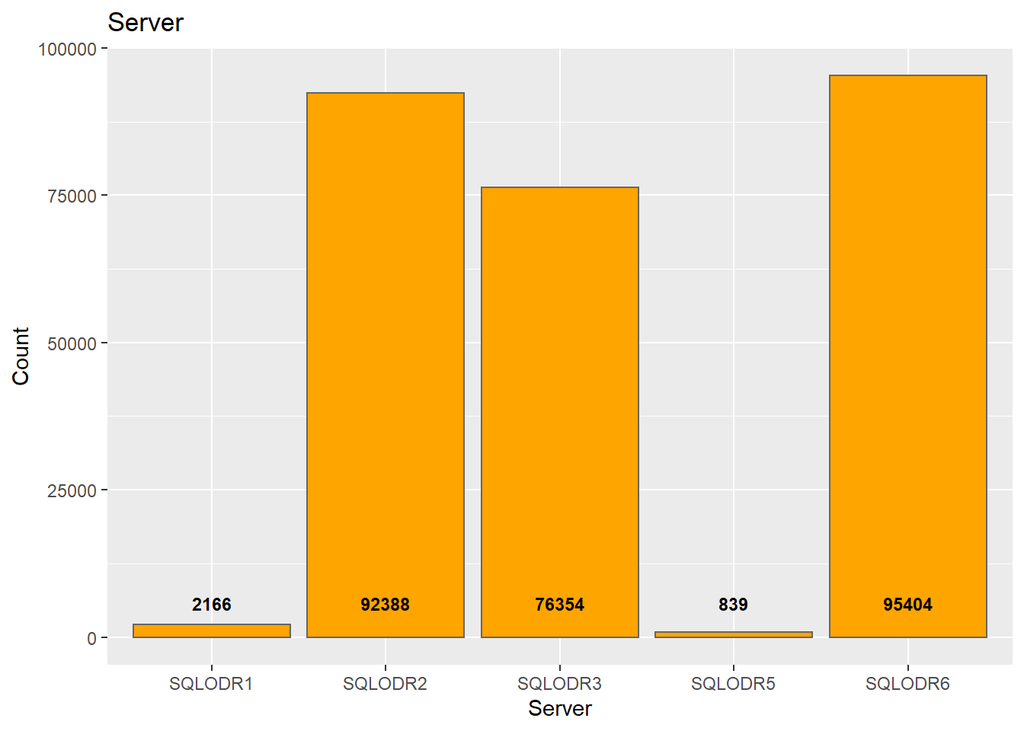

```r
# Plot Category Variables in character or factor
##By Server
reports %>% group_by(Server) %>% dplyr::summarise(Count=n()) %>% ggplot(aes(x=Server, y=Count)) + geom_bar(stat="identity", fill="orange", color="grey40") + labs(title="Server", x="Server",y="Count") + geom_text(aes(x=Server, y=0.01, label= Count), vjust=-2, size=3, colour="black", fontface="bold",angle=360)
```

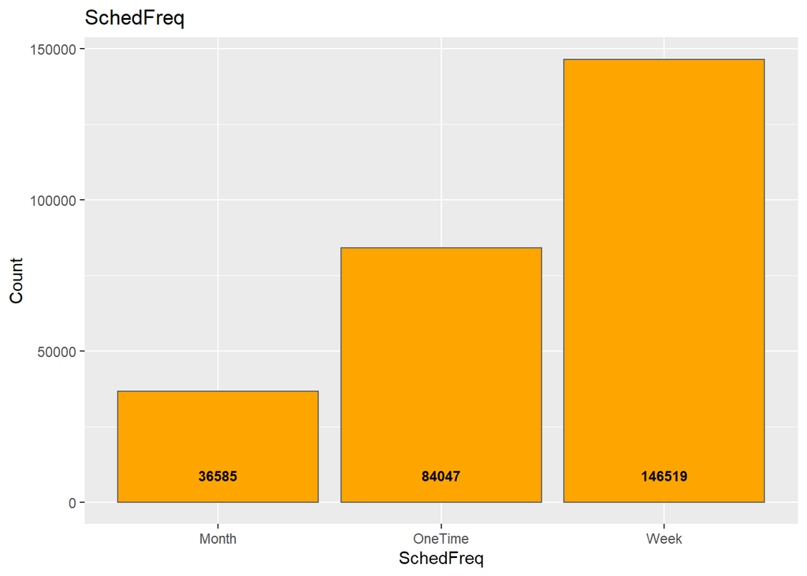

```r
#By SchedFreq
reports %>% group_by(SchedFreq) %>% dplyr::summarise(Count=n()) %>% ggplot(aes(x=SchedFreq, y=Count)) + geom_bar(stat="identity", fill="orange", color="grey40") + labs(title="SchedFreq", x="SchedFreq",y="Count") + geom_text(aes(x=SchedFreq, y=0.01, label= Count), vjust=-2, size=3, colour="black", fontface="bold",angle=360)
```

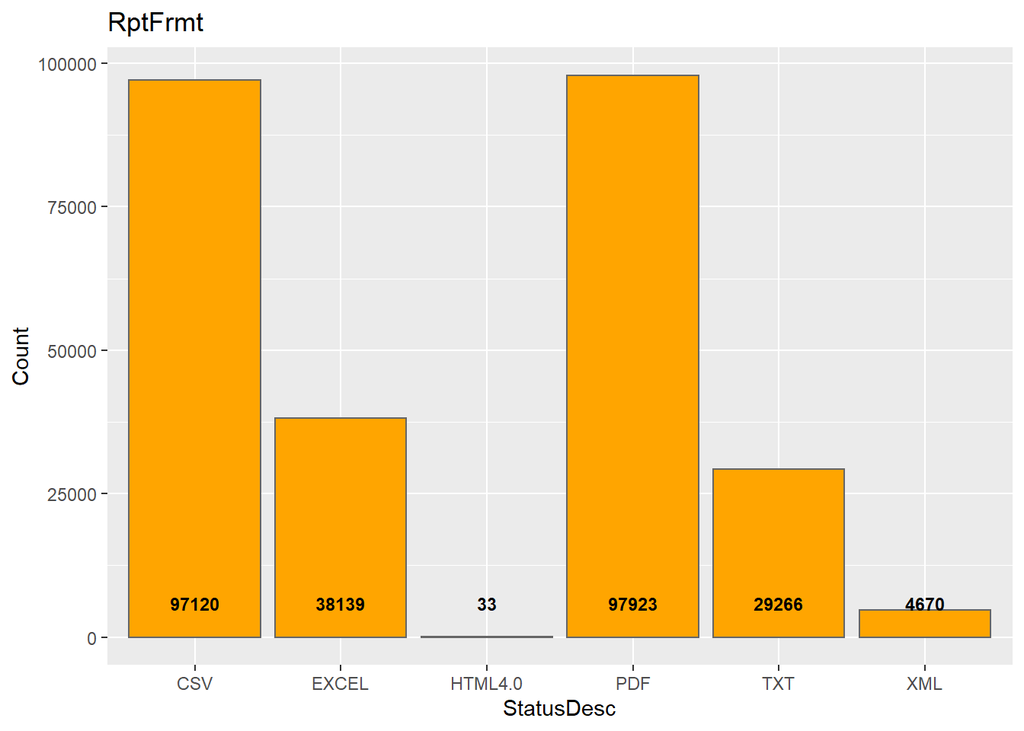

```r
#By RptFrmt
reports %>% group_by(RptFrmt) %>% dplyr::summarise(Count=n()) %>% ggplot(aes(x=RptFrmt, y=Count)) + geom_bar(stat="identity", fill="orange", color="grey40") + labs(title="RptFrmt", x="StatusDesc",y="Count") + geom_text(aes(x=RptFrmt, y=0.01, label= Count), vjust=-2, size=3, colour="black", fontface="bold",angle=360)
```

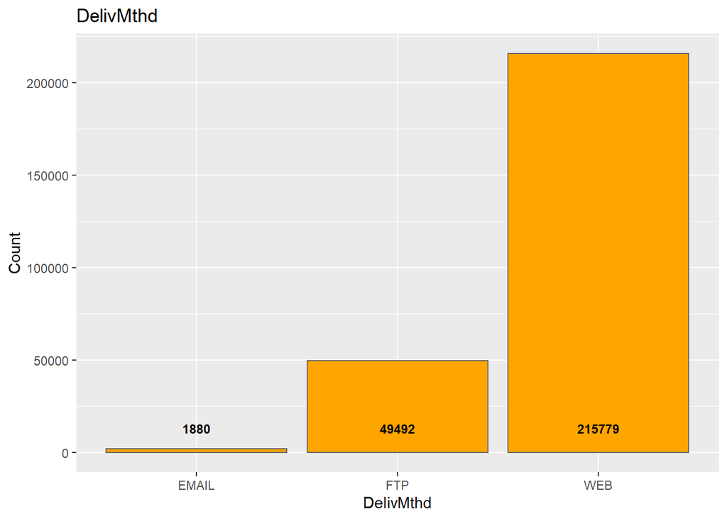

```r
#By DelivMthd
reports %>% group_by(DelivMthd) %>% dplyr::summarise(Count=n()) %>% ggplot(aes(x=DelivMthd, y=Count)) + geom_bar(stat="identity", fill="orange", color="grey40") + labs(title="DelivMthd", x="DelivMthd",y="Count") + geom_text(aes(x=DelivMthd, y=0.01, label= Count), vjust=-2, size=3, colour="black", fontface="bold",angle=360)
```

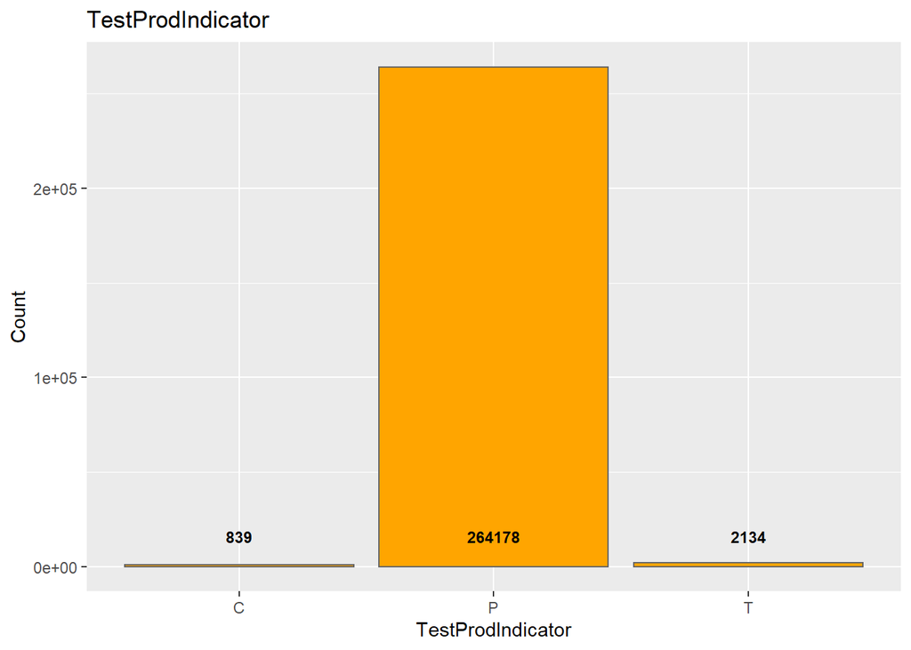

```r
#By TestProdIndicator
reports %>% group_by(TestProdIndicator) %>% dplyr::summarise(Count=n()) %>% ggplot(aes(x=TestProdIndicator, y=Count)) + geom_bar(stat="identity", fill="orange", color="grey40") + labs(title="TestProdIndicator", x="TestProdIndicator",y="Count") + geom_text(aes(x=TestProdIndicator, y=0.01, label= Count), vjust=-2, size=3, colour="black", fontface="bold",angle=360)
```

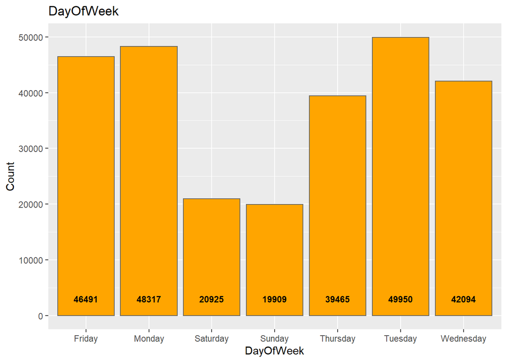

```r
#By ReportStartDay
#reports %>% group_by(ReportStartDay) %>% dplyr::summarise(Count=n()) %>% ggplot(aes(x=ReportStartDay, y=Count)) + geom_bar(stat="identity", fill="orange", color="grey40") + labs(title="ReportStartDay", x="ReportStartDay",y="Count") + geom_text(aes(x=ReportStartDay, y=0.01, label= Count), vjust=-2, size=3, colour="black", fontface="bold",angle=360)

#By DayOfWeek (Duplicate?)
reports %>% group_by(DayOfWeek) %>% dplyr::summarise(Count=n()) %>% ggplot(aes(x=DayOfWeek, y=Count)) + geom_bar(stat="identity", fill="orange", color="grey40") + labs(title="DayOfWeek", x="DayOfWeek",y="Count") + geom_text(aes(x=DayOfWeek, y=0.01, label= Count), vjust=-2, size=3, colour="black", fontface="bold",angle=360)
```

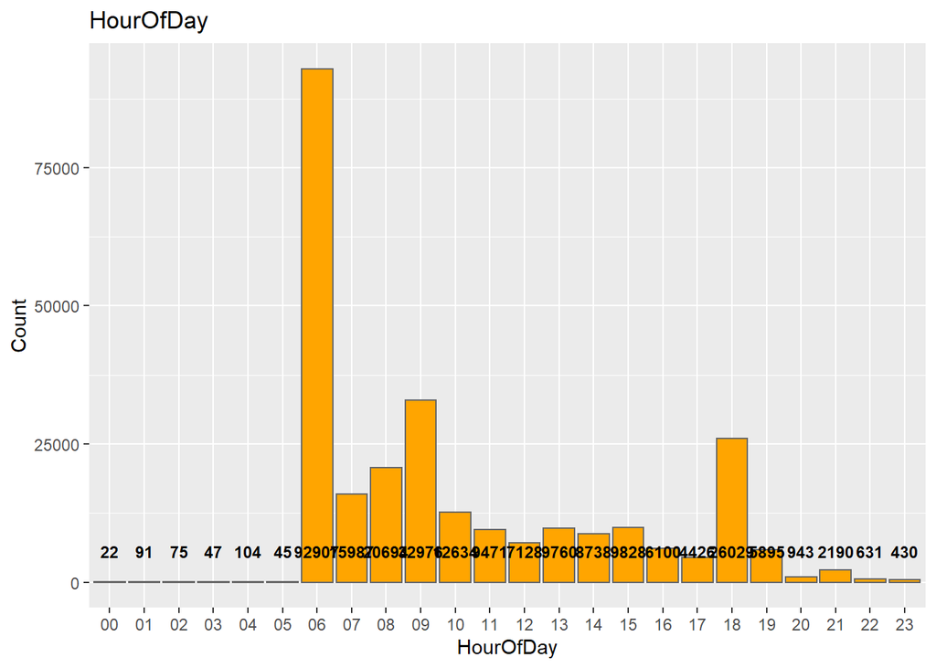

```r
#By HourOfDay
reports %>% group_by(HourOfDay) %>% dplyr::summarise(Count=n()) %>% ggplot(aes(x=HourOfDay, y=Count)) + geom_bar(stat="identity", fill="orange", color="grey40") + labs(title="HourOfDay", x="HourOfDay",y="Count") + geom_text(aes(x=HourOfDay, y=0.01, label= Count), vjust=-2, size=3, colour="black", fontface="bold",angle=360)
```

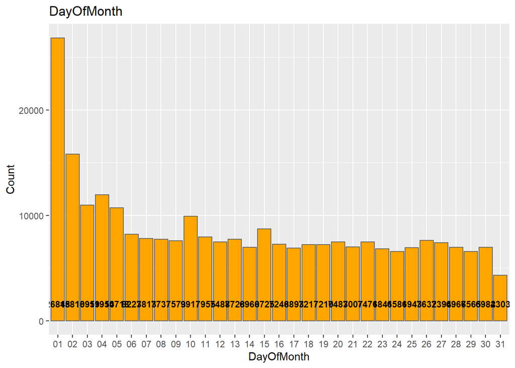

```r
#By DayOfMonth
reports %>% group_by(DayOfMonth) %>% dplyr::summarise(Count=n()) %>% ggplot(aes(x=DayOfMonth, y=Count)) + geom_bar(stat="identity", fill="orange", color="grey40") + labs(title="DayOfMonth", x="DayOfMonth",y="Count") + geom_text(aes(x=DayOfMonth, y=0.01, label= Count), vjust=-2, size=3, colour="black", fontface="bold",angle=360)
```

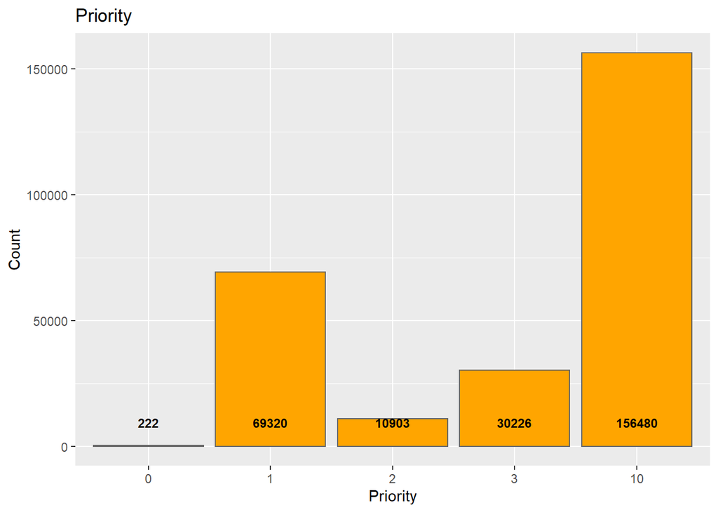

```r
#By Priority
reports %>% group_by(Priority) %>% dplyr::summarise(Count=n()) %>% ggplot(aes(x=Priority, y=Count)) + geom_bar(stat="identity", fill="orange", color="grey40") + labs(title="Priority", x="Priority",y="Count") + geom_text(aes(x=Priority, y=0.01, label= Count), vjust=-2, size=3, colour="black", fontface="bold",angle=360)
```

```r
#By ReportDeliveryTime should be numeric -- delete later
#reports %>% group_by(ReportDeliveryTime) %>% dplyr::summarise(Count=n()) %>% ggplot(aes(x=ReportDeliveryTime, y=Count)) + geom_bar(stat="identity", fill="orange", color="grey40") + labs(title="ReportDeliveryTime", x="ReportDeliveryTime",y="Count") + geom_text(aes(x=ReportDeliveryTime, y=0.01, label= Count), vjust=-2, size=3, colour="black", fontface="bold",angle=360)
```

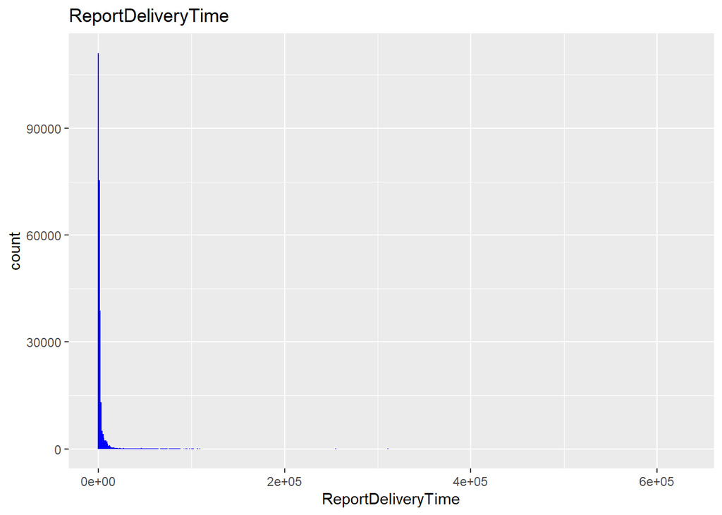

```r
# Plot Numerical Variables

##By ReportDeliveryTime
reports$ReportDeliveryTime = as.numeric(reports$ReportDeliveryTime)
ggplot(data=reports[!is.na(reports$ReportDeliveryTime),], aes(x=ReportDeliveryTime)) +
        geom_histogram(fill="blue", binwidth = 1000) + labs(title="ReportDeliveryTime", x="ReportDeliveryTime")
```

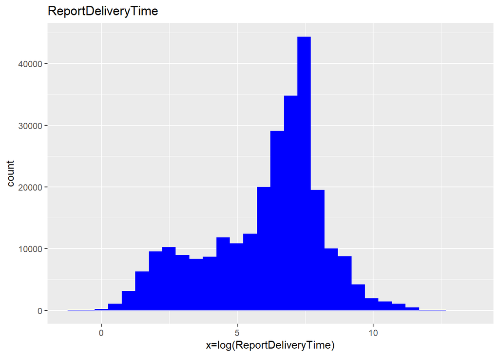

```r
##By ReportDeliveryTime -- Take log
reports$ReportDeliveryTime = as.numeric(reports$ReportDeliveryTime)
ggplot(data=reports[!is.na(reports$ReportDeliveryTime),], aes(x=log(ReportDeliveryTime))) +
        geom_histogram(fill="blue") + labs(title="ReportDeliveryTime", x="x=log(ReportDeliveryTime)")
```

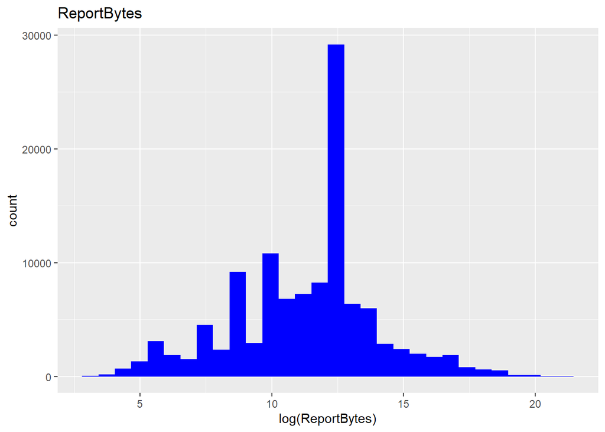

```r
##By ReportBytes
reports_sizel0 <- reports %>% filter(reports$ReportBytes > 0)
ggplot(data=reports_sizel0,aes(x=log(reports_sizel0$ReportBytes))) + geom_histogram(fill="blue") + labs(title="ReportBytes", x="log(ReportBytes)")
```

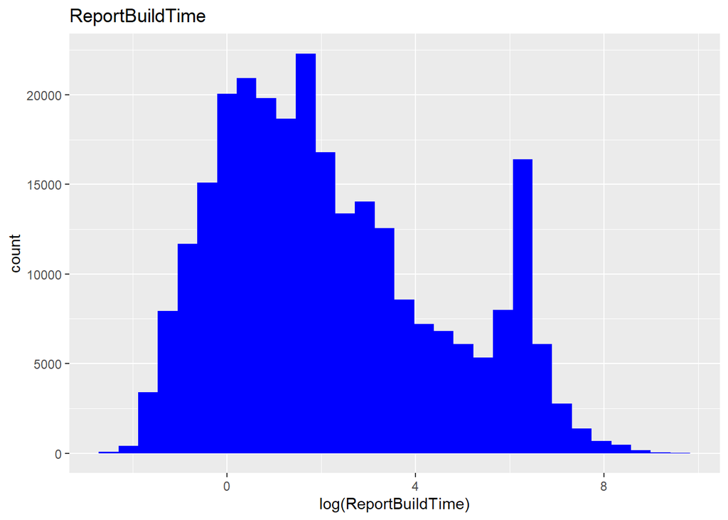

```r
##By ReportBuildTime
reports$ReportBuildTime = as.numeric(reports$ReportBuildTime)
ggplot(data=reports[!is.na(reports$ReportBuildTime),], aes(x=log(ReportBuildTime))) +
        geom_histogram(fill="blue") + labs(title="ReportBuildTime", x="log(ReportBuildTime)")
```

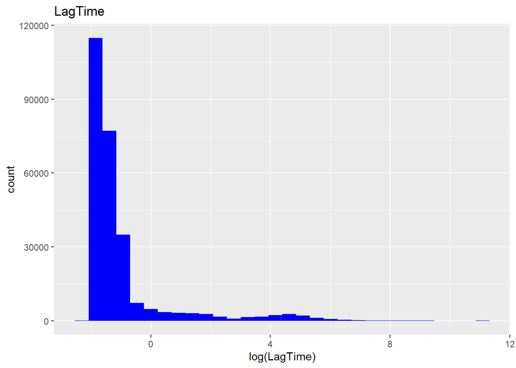

```r
##By LagTime
reports$LagTime = as.numeric(reports$LagTime)
ggplot(data=reports[!is.na(reports$LagTime),], aes(x=log(LagTime))) +
        geom_histogram(fill="blue") + labs(title="LagTime", x="log(LagTime)")
```

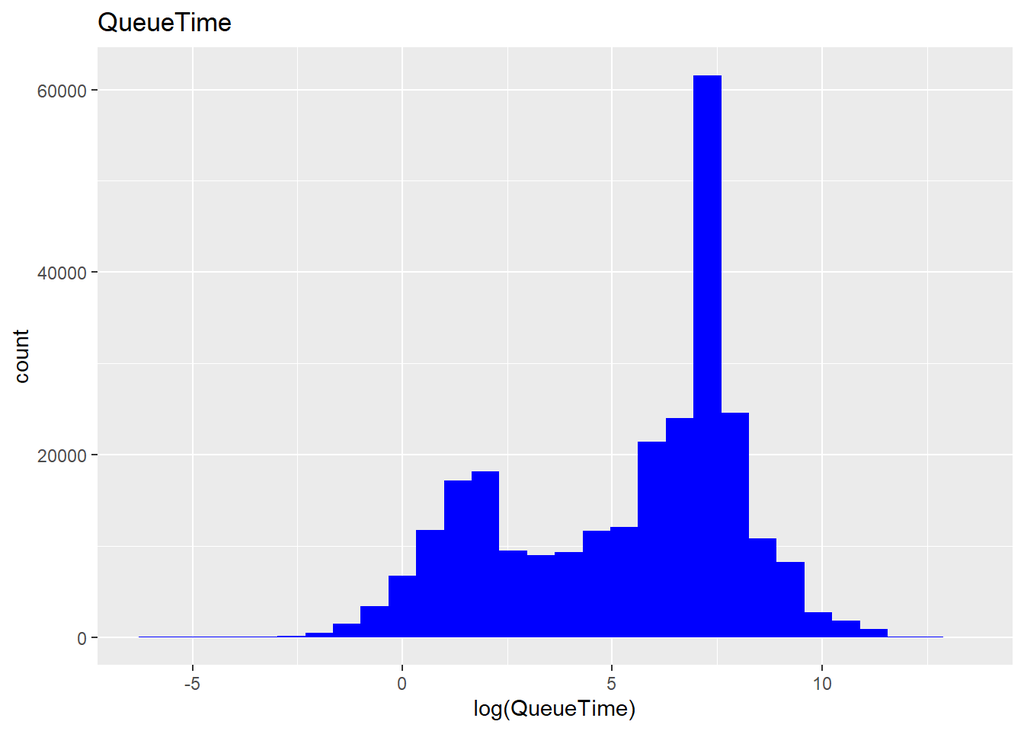

```r
##By QueueTime
reports$QueueTime = as.numeric(reports$QueueTime)
ggplot(data=reports[!is.na(reports$QueueTime),], aes(x=log(QueueTime))) +
        geom_histogram(fill="blue") + labs(title="QueueTime", x="log(QueueTime)")
```

Observations: -The following numric variables not displayed much variations by servers. Only Delivery/Queue time desplay different feature with server 6/2/3 compared with server 1/5.

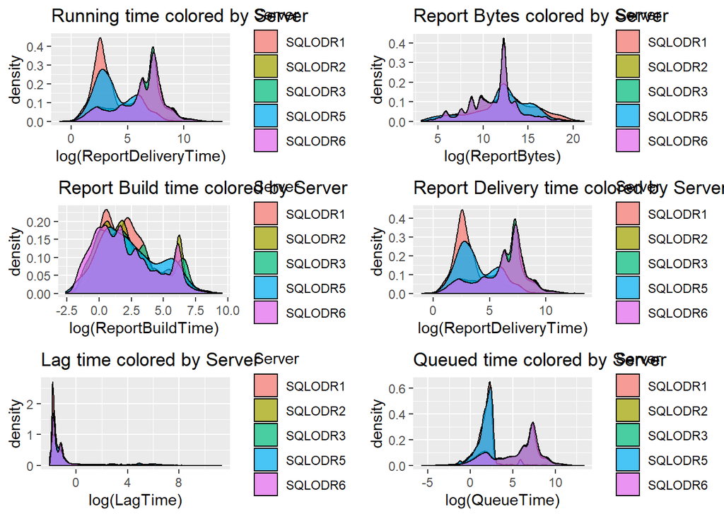

```r
#reports %>% select(ReportDeliveryTime, Server) %>% group_by(ReportDeliveryTime, Server) %>% summarize(n=n()) %>% ggplot(aes(x=Server, y=n) + geom_density(alpha = 0.7)

g1 <- reports %>% ggplot(aes(x=log(ReportDeliveryTime), fill=Server)) + geom_density(alpha = 0.7) + labs(title="Running time colored by Server")
g2 <- reports %>% ggplot(aes(x=log(ReportBytes), fill=Server)) + geom_density(alpha = 0.7) + labs(title="Report Bytes colored by Server")

g3 <- reports %>% ggplot(aes(x=log(ReportBuildTime), fill=Server)) + geom_density(alpha = 0.7) + labs(title="Report Build time colored by Server")

g4 <- reports %>% ggplot(aes(x=log(ReportDeliveryTime), fill=Server)) + geom_density(alpha = 0.7) + labs(title="Report Delivery time colored by Server")

g5 <- reports %>% ggplot(aes(x=log(LagTime), fill=Server)) + geom_density(alpha = 0.7) + labs(title="Lag time colored by Server")

g6 <- reports %>% ggplot(aes(x=log(QueueTime), fill=Server)) + geom_density(alpha = 0.7) + labs(title="Queued time colored by Server")

grid.arrange(g1,g2,g3,g4,g5,g6,ncol = 2, nrow = 3)
```

Observations: -No obvious differences are observed with discrete variables for server 2,3 and 6.

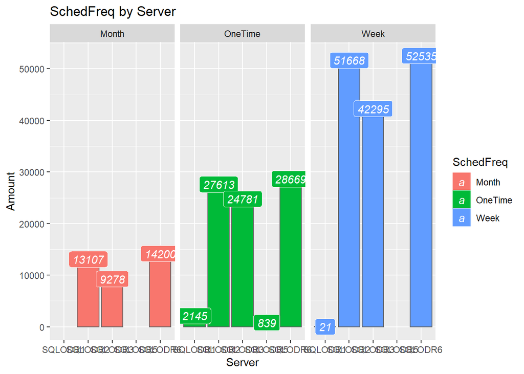

```r
reports %>% dplyr::select(SchedFreq, Server) %>% group_by(SchedFreq, Server) %>% dplyr::summarize(n=n()) %>% ggplot(aes(x=Server, y=n, fill=SchedFreq, color=SchedFreq)) + geom_bar(stat="identity", color="grey40") + facet_wrap(~SchedFreq) + geom_label(aes(label=n, fill = SchedFreq), colour = "white", fontface = "italic") +
    labs(title="SchedFreq by Server", x="Server",y="Amount")
```

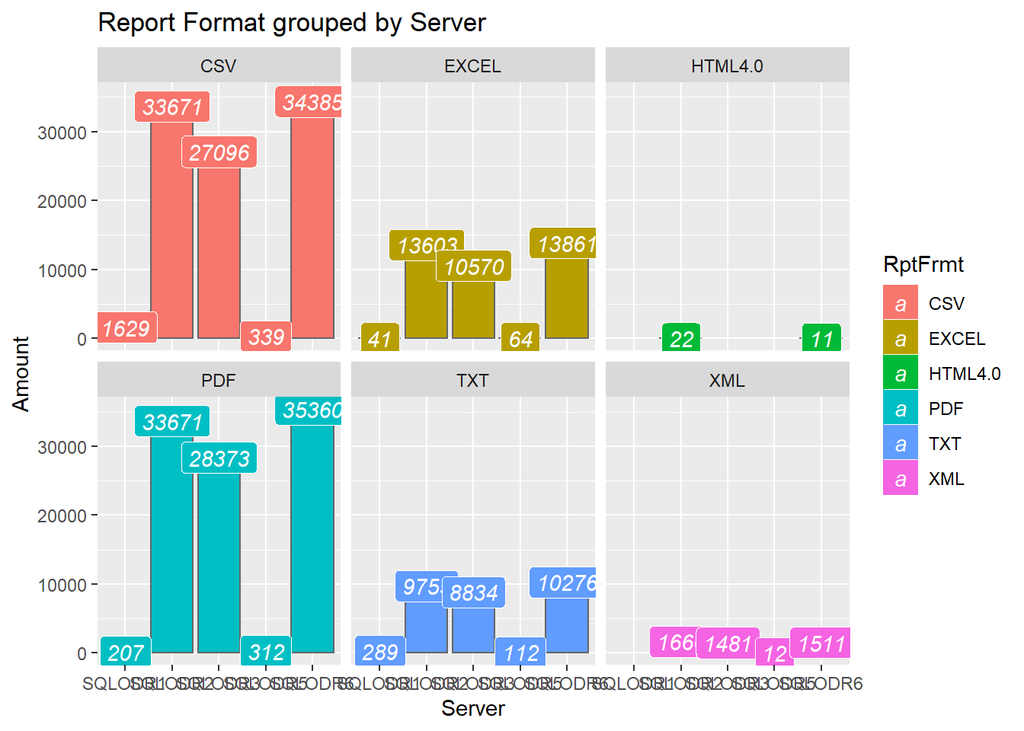

```r
reports %>% dplyr::select(RptFrmt, Server) %>% group_by(RptFrmt, Server) %>% dplyr::summarize(n=n()) %>% ggplot(aes(x=Server, y=n, fill=RptFrmt, color=RptFrmt)) + geom_bar(stat="identity", color="grey40") + facet_wrap(~RptFrmt) + geom_label(aes(label=n, fill = RptFrmt), colour = "white", fontface = "italic") +
    labs(title="Report Format grouped by Server", x="Server",y="Amount")
```

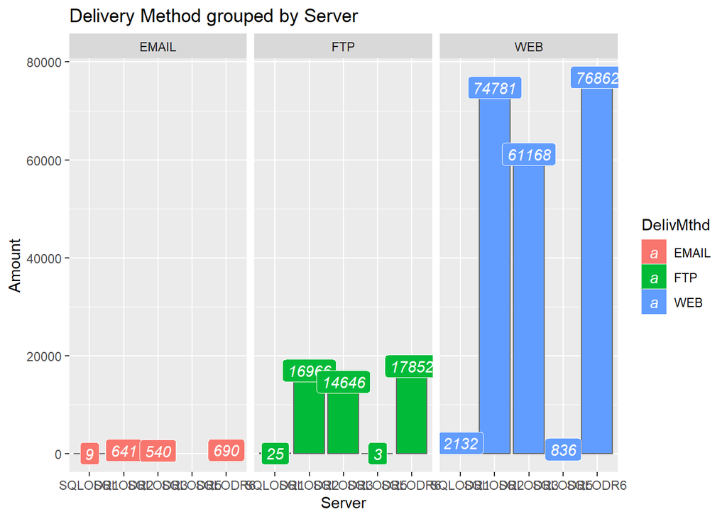

```r
#reports %>% dplyr::select(RptFrmt, Server) %>% group_by(RptFrmt, Server) %>% dplyr::summarize(n=n()) %>% ggplot(aes(x=RptFrmt, y=n, fill=Server, color=Server)) + geom_bar(stat="identity", color="grey40") + facet_wrap(~Server) + geom_label(aes(label=n, fill = Server), colour = "white", fontface = "italic") + labs(title="Server by Report Format", x="Server",y="Amount") + geom_text(aes(x=RptFrmt, y=0.01, label= n),vjust=-2)

reports %>% dplyr::select(DelivMthd, Server) %>% group_by(DelivMthd, Server) %>% dplyr::summarize(n=n()) %>% ggplot(aes(x=Server, y=n, fill=DelivMthd, color=DelivMthd)) + geom_bar(stat="identity", color="grey40") + facet_wrap(~DelivMthd) + geom_label(aes(label=n, fill = DelivMthd), colour = "white", fontface = "italic") +
    labs(title="Delivery Method grouped by Server", x="Server",y="Amount")
```

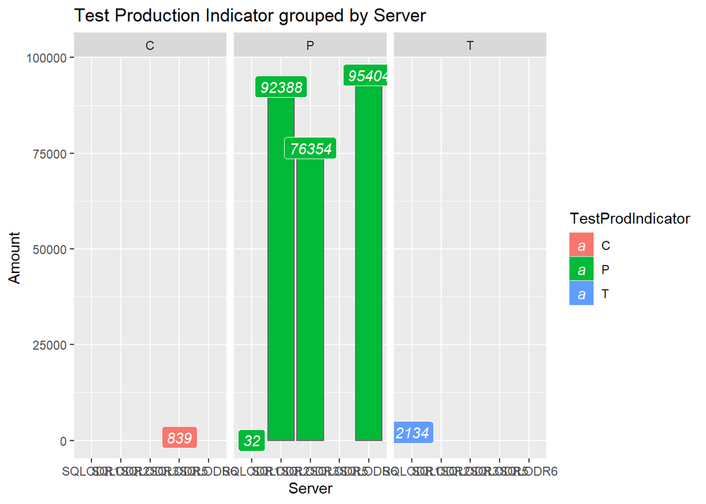

```r
reports %>% dplyr::select(TestProdIndicator, Server) %>% group_by(TestProdIndicator, Server) %>% dplyr::summarize(n=n()) %>% ggplot(aes(x=Server, y=n, fill=TestProdIndicator, color=TestProdIndicator)) + geom_bar(stat="identity", color="grey40") + facet_wrap(~TestProdIndicator) + geom_label(aes(label=n, fill = TestProdIndicator), colour = "white", fontface = "italic") +
    labs(title="Test Production Indicator grouped by Server", x="Server",y="Amount")
```

```r
#reports %>% dplyr::select(ReportStartDay, Server) %>% group_by(ReportStartDay, Server) %>% dplyr::summarize(n=n()) %>% ggplot(aes(x=Server, y=n, fill=ReportStartDay, color=ReportStartDay)) + geom_bar(stat="identity", color="grey40") + facet_wrap(~ReportStartDay) + geom_label(aes(label=n, fill = ReportStartDay), colour = "white", fontface = "italic") +
    labs(title="Report Start Day grouped by Server", x="Server",y="Amount")
```

```
## $x
## [1] "Server"
##
## $y
## [1] "Amount"
##
## $title
## [1] "Report Start Day grouped by Server"
##
## attr(,"class")
## [1] "labels"
```

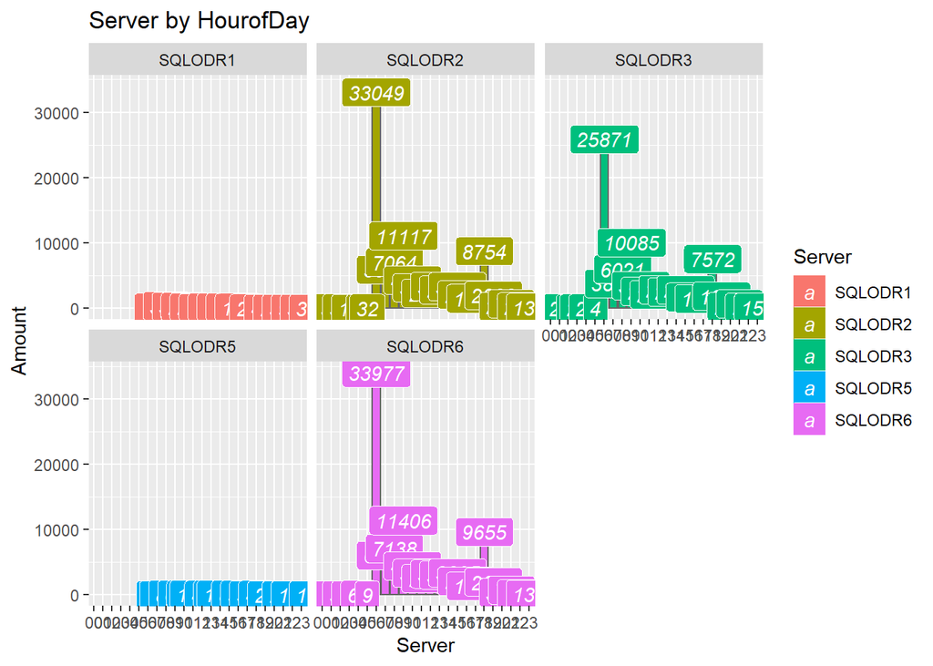

```r
###

reports %>% dplyr::select(HourOfDay, Server) %>% group_by(HourOfDay, Server) %>% dplyr::summarize(n=n()) %>% ggplot(aes(x=HourOfDay, y=n, fill=Server, color=Server)) + geom_bar(stat="identity", color="grey40") + facet_wrap(~Server) + geom_label(aes(label=n, fill = Server), colour = "white", fontface = "italic") + labs(title="Server by HourofDay", x="Server",y="Amount")
```

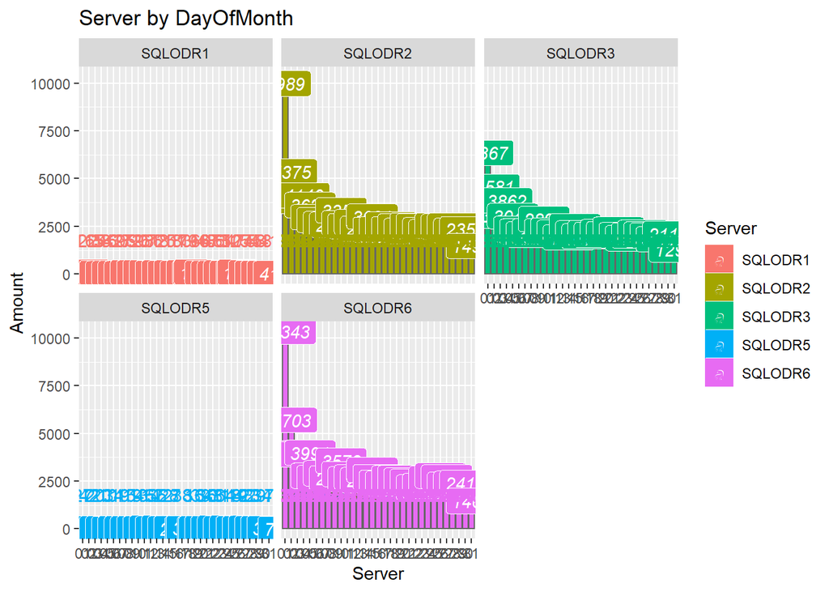

```r
reports %>% dplyr::select(DayOfMonth, Server) %>% group_by(DayOfMonth, Server) %>% dplyr::summarize(n=n()) %>% ggplot(aes(x=DayOfMonth, y=n, fill=Server, color=Server)) + geom_bar(stat="identity", color="grey40") + facet_wrap(~Server) + geom_label(aes(label=n, fill = Server), colour = "white", fontface = "italic") + labs(title="Server by DayOfMonth", x="Server",y="Amount") + geom_text(aes(x=DayOfMonth, y=0.01, label= n),vjust=-2)
```

```r
#reports %>% ggplot(aes(x=log(ReportDeliveryTime), fill=Server)) + geom_histogram()
```

Observations: -RptFrmt is an important factor of differenciating running times.

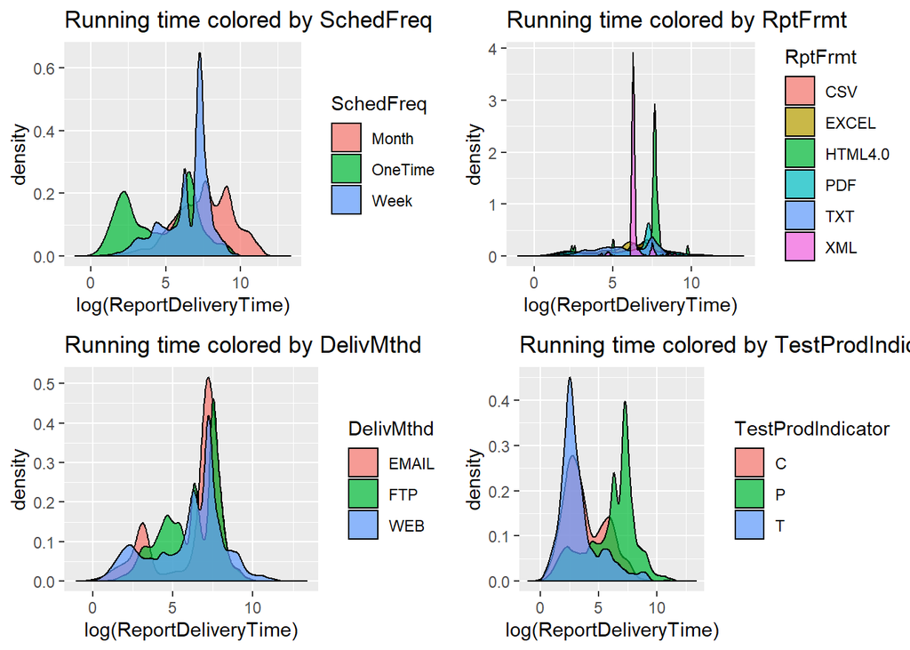

```r
g7 <- reports %>% ggplot(aes(x=log(ReportDeliveryTime), fill=SchedFreq)) + geom_density(alpha = 0.7) + labs(title="Running time colored by SchedFreq")

g8 <- reports %>% ggplot(aes(x=log(ReportDeliveryTime), fill=RptFrmt)) + geom_density(alpha = 0.7) + labs(title="Running time colored by RptFrmt")

g9 <- reports %>% ggplot(aes(x=log(ReportDeliveryTime), fill=DelivMthd)) + geom_density(alpha = 0.7) + labs(title="Running time colored by DelivMthd")

g10 <- reports %>% ggplot(aes(x=log(ReportDeliveryTime), fill=TestProdIndicator)) + geom_density(alpha = 0.7) + labs(title="Running time colored by TestProdIndicator")

grid.arrange(g7,g8,g9,g10,ncol = 2, nrow = 2)
```

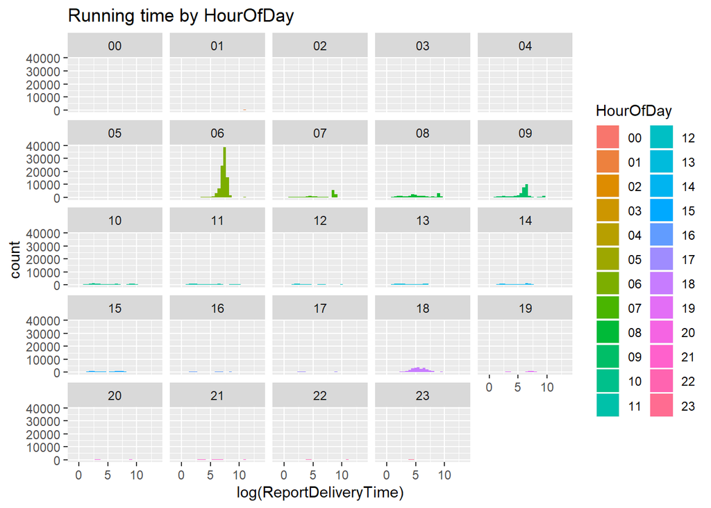

```r
reports %>% ggplot(aes(x=log(ReportDeliveryTime), fill=HourOfDay)) + geom_histogram() + labs(title="Running time by HourOfDay") + facet_wrap(~HourOfDay)
```

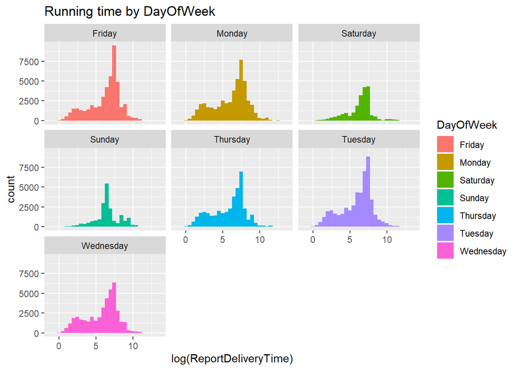

```r
reports %>% ggplot(aes(x=log(ReportDeliveryTime), fill=DayOfWeek)) + geom_histogram() + labs(title="Running time by DayOfWeek") + facet_wrap(~DayOfWeek)
```

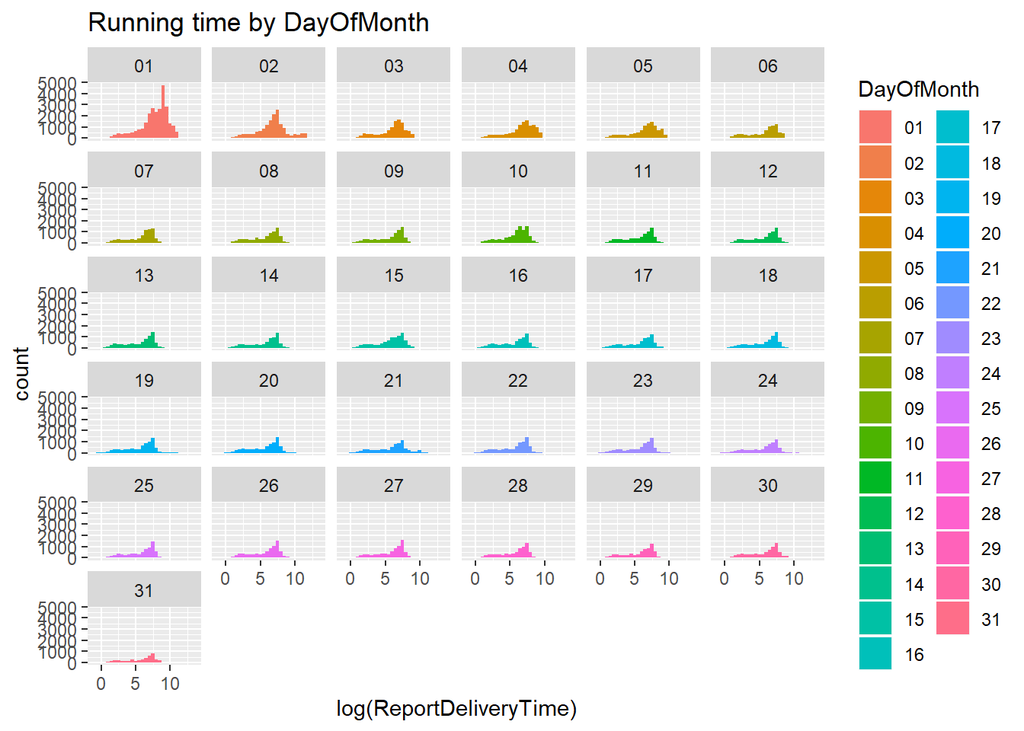

```r
reports %>% ggplot(aes(x=log(ReportDeliveryTime), fill=DayOfMonth)) + geom_histogram() + labs(title="Running time by DayOfMonth") + facet_wrap(~DayOfMonth)
```

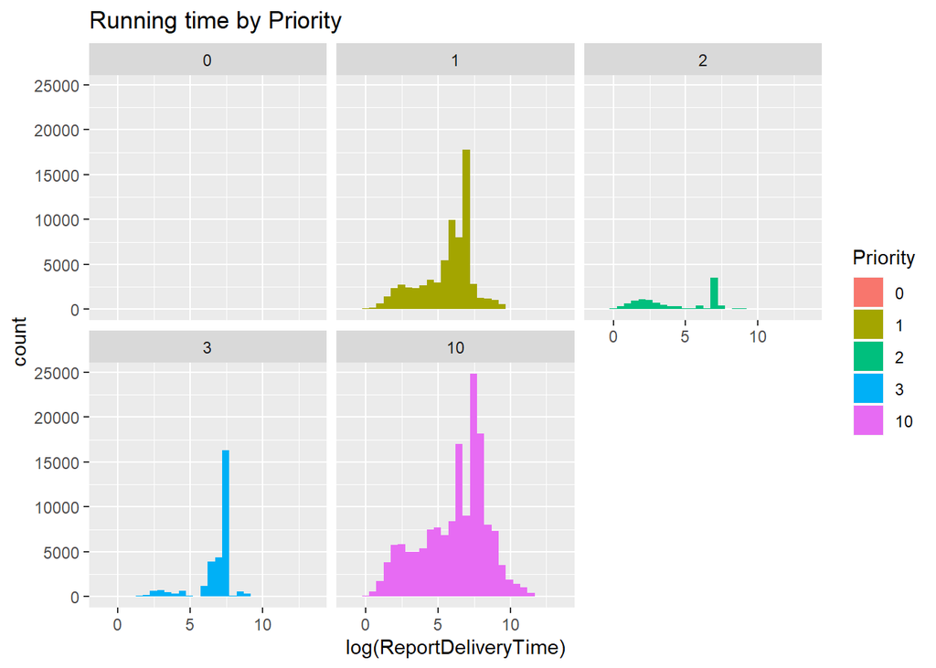

```r
reports %>% ggplot(aes(x=log(ReportDeliveryTime), fill=Priority)) + geom_histogram() + labs(title="Running time by Priority") + facet_wrap(~Priority)
```

Observations: -Running time is best correlated with report building time with exceptions in smaller numbers. -Delivery time are all bigger than running time which is consisitent with intuition. -No obvious trends observed with it together with Lag/Queue Time. -ReportBytes are correlated with Running time by large variations. No running time/report bytes differences observed by server.

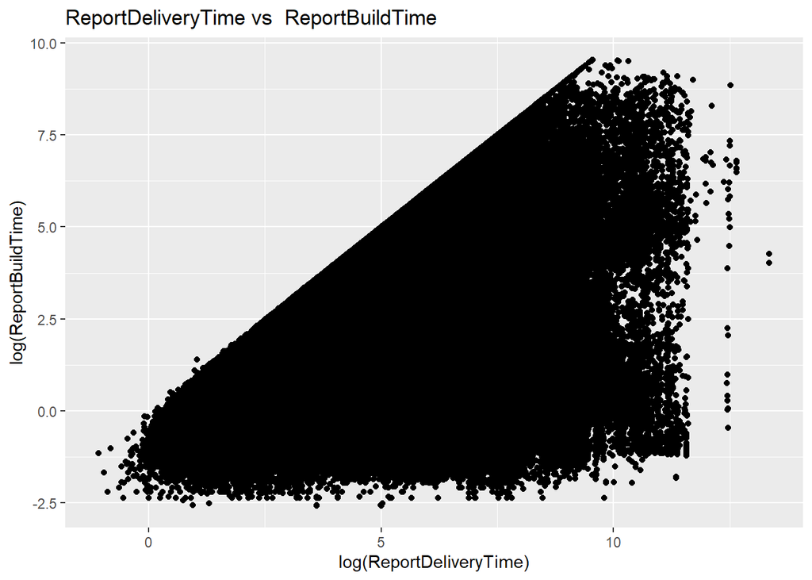

```r
reports %>% dplyr::select(ReportDeliveryTime, ReportBuildTime) %>%
ggplot(aes(x=log(ReportDeliveryTime), y=log(ReportBuildTime)))+ geom_point() + labs(title="ReportDeliveryTime vs  ReportBuildTime", x="log(ReportDeliveryTime)",y="log(ReportBuildTime)")
```

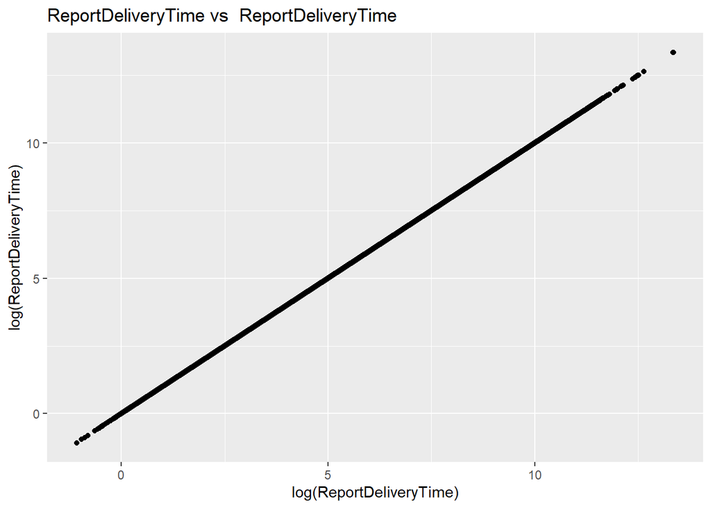

```r
reports %>% dplyr::select(ReportDeliveryTime, ReportDeliveryTime) %>%
ggplot(aes(x=log(ReportDeliveryTime), y=log(ReportDeliveryTime)))+ geom_point() + labs(title="ReportDeliveryTime vs  ReportDeliveryTime", x="log(ReportDeliveryTime)",y="log(ReportDeliveryTime)")
```